# Assignment 5: Environmental equity, access to natural areas

## Overview

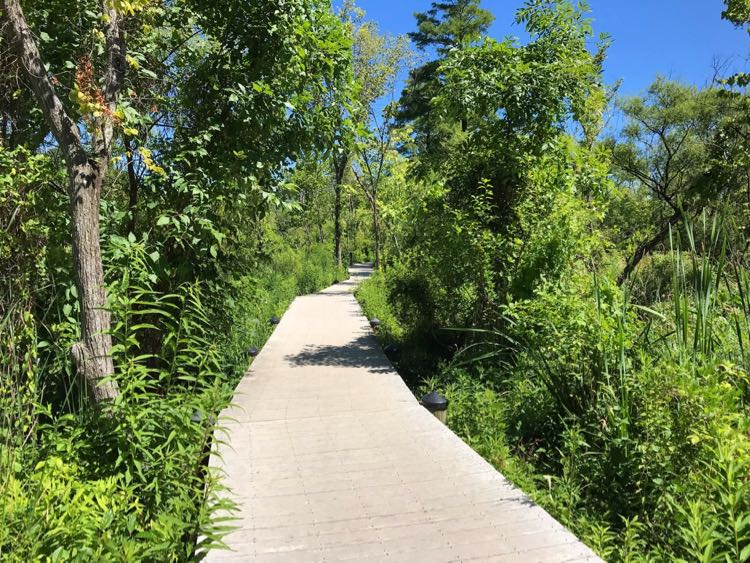

*A trail on DC’s Roosevelt Island.*

Free play in “nature” is expected to positively impact childhood development. In this assignment we will address the idea of *environmental equity* in Washington DC, specifically in regards to access to wild green spaces in the city. Socioeconomic status has been found to be a strong determinant of whether children have access to such spaces.

In this exercise, you will use raster data and shapefiles to explore the distribution of forest in the city.

When I create an R Markdown file to communicate a coding process, I usually work in a .R script file and copy-and-paste the code into the R Markdown document at the end.

**Important**

To receive full credit for a given question, please ensure that the result you provide **only** answers the given question. For example, in the table below, if you were asked to determine the value in column `b` where column `a` is equal to “hello” you would provide the following code:

```r
tibble(
  a = c('hello', 'world'),
  b = 1:2) %>%
  filter(a == 'hello') %>%
  pull(b)
```

```
## [1] 1
```

## Grading

The points allotted for each question are provided in highlighted red bold text (e.g., [1.0]) within the question itself. When applicable, total points for a question may represent the sum of individually graded components, which are provided in red text (e.g., [1.0]).

**Points may be deducted from each question’s total:**

- Use only functions other than those listed in “Functions that you may use in this assignment” [50%]
- Do not include any assignments other than those specified in the question [50%]
- Unless specified otherwise, each question must be answered in a single piped statement [50%]
- Include a comment at the start of each code block [25%]
- Include a comment for each line of code that modifies a dataset [10% per violation]
- Ensure that all code is properly indented [10% per violation]
- Ensure that your code follows modern coding conventions (see *Best practices in modern R coding*) [10% per violation]

*Note: The maximum deduction is the total points value for a given question*

You must ensure that your R Markdown document **runs out-of-the-box** – in other words, the document will knit without error. Some tips for doing so:

- Do not maintain your project folder in a location that is backed up by an online directory (e.g., Dropbox, iCloud)
- Ensure that all file paths are equivalent to those in this document (e.g., in `source()` or `read_csv()`)
- Do not use `setwd()` in your code (**Never** use `setwd()`!)
- If one of your code chunks contains an error, include `eval = FALSE` in the options for that chunk
- Prior to submission, clear all objects from your global environment prior to knitting your R Markdown document

In this assignment, you may use **only** the following R functions (*Note: If you are unclear on what a given function does, use `?` to view the help file!*):

- base:: ::
- base::<-
- base::=
- base::==
- base::>=
- base::+
- base::$
- base::!
- base::~
- base::(
- base::)
- base::as.matrix
- base::c
- base::cut
- base::is.na
- base::library
- base::mean
- base::rm
- base::source
- dplyr::case_when
- dplyr::if_else
- dplyr::filter
- dplyr::group_by
- dplyr::mutate
- dplyr::pull
- dplyr::summarize
- dplyr::transmute
- forcats::fct_recode
- forcats::fct_relevel
- magrittr::%>%
- stringr::str_detect
- terra::classify
- terra::extract
- terra::rasterize
- tibble::tibble
- tibble::tribble
- tmap::tm_basemap
- tmap::tm_polygons
- tmap::tm_raster
- tmap::tm_shape
- tmap::tmap_mode
- tmap::tmap_options

*Note: The packages dplyr, ggplot2, magrittr, readr, rlang, and tibble are all part of the tidyverse and are loaded with `library(tidyverse)`.*

## Getting started

Open R Studio. Please ensure that the Global Options for R Markdown are set to “Show output preview in Viewer Pane”. This will allow you to view the knitted document (i.e., the html version of this file) right next to your code.

As always, please ensure that you are starting with a clean session. Please do the following before continuing:

- If there are any script files open in your source pane. Close them. If any of the file titles are blue, save them prior to closing.
- In the *Environment* tab of your **workspace pane**, ensure that your **global environment** is empty. If it is not, click the *broom* to remove all objects.
- In the *History* tab of your **workspace pane**, ensure that your history is empty. If it is not, click the *broom* to remove your history.

1. [0.5] Save and knit this document:

## The setup

**All** of my scripts start with a setup section where I load libraries, set session options, conduct initial data loading, and early processing steps.

2. [0.5] Load the `sf`, `tmap`, and `tidyverse` libraries.

```r
# Paste your code in here!
```

3. [0.5] Load the data from the source script `source_script_bird_mortality.R` [0.25] and set the tmap mode to “view” for the entire document [0.25].

```r
# Paste your code in here!
```

The code below is necessary due to a current bug and an issue during on-the-fly reprojections that occur under-the-hood in tmap. Please run it:

```r
tmap::tmap_options(check.and.fix = TRUE)
```

[output not shown]

We will not use the `birds` or `cicadas` files, so please run the code below to remove the objects from your global environment:

```r
rm(cicadas, birds)
```

4. [1.0] Convert the `census` data to a `SpatRaster` object:

- [0.5] With the same resolution and extent as `rasters`;
- [0.3] With values based on the field `income`;
- [0.1] Assign the name `income_dc` to the resultant object;

```r
# Paste your code in here!
```

- [0.1] Remove `census` from your global environment:

```r
# Paste your code in here!
```

5. [1.0] The DC parks and recreation department seeks to create green space for children and adults alike. This dataset contains the field “woodland” to describe the type of park. Using `parks_and_rec`:

- [0.2] Subset DC parks to those where the values in `woodland` are not NA;
- [0.4] Without using `if_else` or `case_when`, add a field called `park_type` in which you reclassify `woodland` into the values “Forested” (`woodland == "Y"`) and Not forested” (`woodland == "N"`)
- [0.2] As parsimoniously as possible, subset the data to the columns objectid and `park_type`;
- [0.1] Assign to the global environment with the name `dc_parks`;

```r
# Paste your code in here!
```

- [0.1] Remove `parks_and_rec` from your global environment:

```r
# Paste your code in here!
```

6. [1.0] Using `nlcd_key`, create a reclass matrix where:

- [0.2] Water is given the value NA;
- [0.15] Developed land cover classes are mapped to the value 1;
- [0.15] Forest land cover classes are mapped to the value 2;
- [0.15] All other classes are mapped to the value 3;
- [0.15] The resultant object is a matrix;
- [0.1] The object is assigned to the global environment with the name `rcl_nlcd`;

```r
# Paste your code in here!
```

- [0.1] Remove `nlcd_key` from your global environment:

```r
# Paste your code in here!
```

7. [0.5] Using `rcl_nlcd` and `rasters$nlcd`:

- [0.3] Reclassify the `nlcd` raster such that it represents the developed (value = 1), forested (value = 2), and undeveloped open land (value = 3) land cover types in Washington DC;
- [0.1] Assign the object to your global environment with the name “developed_and_forested_land”;

```r
# Paste your code in here!
```

- [0.1] Remove `rcl_nlcd` from your global environment:

```r
# Paste your code in here!
```

8. [1.5] Impervious surface, which represents things like roads, sidewalks, and rooftops, is often used as a proxy for urban intensity. Our goal will be to classify the impervious surface raster (`rasters$imp`) into low (< 20% impervious surface), medium (20 through < 80% impervious surface), and high intensity (>= 80% impervious surface).

- [0.5] Using the above criteria, create a reclass matrix that can be used to classify the `rasters$imp` to the numeric values 1 (low), 2 (medium), and 3 (high);
- [0.1] Assign the object to the global environment with the name `urban_rcl`;

```r
# Paste your code in here!
```

Every time I classify a numeric raster, I first test what will happen when I supply different values for the `include.lowest` and `right` arguments. To do so, I generate a tibble of values that is sparse enough to see the whole tibble at once in the console pane. When working with percentages, I use the values 0 through 10 to represent 0 through 100%. I then add a new classified column using `cut()` and explore the behavior at the margins of each group.

- [0.3] Modify the code block below to determine the combination of `include.lowest` and `right` arguments that will generate the desired land cover classes;

```r
# Modify me!

tibble(values = 0:10) %>%
  mutate(
    classes =
      cut(values,
          breaks = c(0, 2, 8, 10)))
```

```
## # A tibble: 11 × 2
##    values classes
##     <int> <fct>
##  1      0 <NA>
##  2      1 (0,2]
##  3      2 (0,2]
##  4      3 (2,8]
##  5      4 (2,8]
##  6      5 (2,8]
##  7      6 (2,8]
##  8      7 (2,8]
##  9      8 (2,8]
## 10      9 (8,10]
## 11     10 (8,10]
```

- [0.4] Use `urban_rcl` to classify the `rasters$imp`
- [0.1] Assign to your global environment with the name `urban_intensity`.

```r
# Paste your code in here!
```

- [0.1] Remove urban_rcl and from your global environment:

```r
# Paste your code in here!
```

9. [2.0] National Park Service land in Washington DC includes everything from traffic circles and monuments to intact patches of deciduous forest. Working with the file `nps`:

- [0.3] Filter to features where the `name` includes the string “Park ” (with the trailing space!) or “Parkway” ;
- [0.3] Combine the geometries of parks that share the same name;
- [0.3] Add a field that represents the average canopy cover for each park;
- [0.3] Using greater than or equal to 60% canopy as your criteria, add a field called `park_type` that represents whether a park is, on average, “Forested” or “Not Forested” ;
- [0.3] Ensure that the levels of `park_type` are provided in the order: “Not Forested”, “Forested”;
- [0.3] Remove the `canopy` and `name` fields as parsimoniously as possible; *Hint: Notice that the `select` function isn’t on the approved functions list this time?*
- [0.1] **Assign** the resultant object to your global environment with the name “nps_parks”;

```r
# Paste your code in here!
```

- [0.1] Remove `nps` and `rasters` from your global environment:

```r
# Paste your code in here!
```

```r
# Paste your code in here!
```

**Extra credit** [0.25]: You most likely have a duplicated legend. Check out the help file for `tm_polygons()` and remove one of the legends.

Now that you’ve completed the code, take a look at the maps you’ve created. Does DC do a good job of providing forested spaces across all income levels in the city? In my opinion, a case could be made for some success despite socioeconomic clustering *and* much more work to do because of socioeconomic clustering!

If you’re guessing that we’ll be exploring these patterns a bit further next week …